# Análisis Estadístico con `psych` y Visualización con Factores

Ricardo Macías Bohórquez

21 de October de 2024

# Análisis Estadístico con `psych` y Visualización con Factores

En este análisis, realizaremos una exploración estadística más profunda del conjunto de datos `mtcars` utilizando la librería **`psych`**, y aprenderemos a generar visualizaciones avanzadas, incluyendo **boxplots** con múltiples factores.

## 1. Exploración de Datos con `psych`

### 1.1 Cargar las librerías necesarias

```r
# Instalar y cargar las librerías necesarias
# install.packages("psych")
# install.packages("ggplot2")
# install.packages("data.table")

library(data.table)
library(psych)
library(ggplot2)
```

### 1.2 Cargar el conjunto de datos `mtcars`

```r
# Convertir mtcars a data.table
dt_mtcars <- as.data.table(mtcars)
```

## 2. Análisis Estadístico con `psych`

### 2.1 Descripción de los datos con `describe()`

La función `describe()` de `psych` proporciona una descripción detallada de cada variable, incluyendo medidas de centralidad (media, mediana), dispersión (desviación estándar), asimetría, curtosis, entre otras.

```r
# Describir las variables de mtcars
descripcion_mtcars <- describe(dt_mtcars)
print(descripcion_mtcars)
```

```
##      vars  n   mean     sd median trimmed    mad   min    max  range  skew
## mpg     1 32  20.09   6.03  19.20   19.70   5.41 10.40  33.90  23.50  0.61
## cyl     2 32   6.19   1.79   6.00    6.23   2.97  4.00   8.00   4.00 -0.17
## disp    3 32 230.72 123.94 196.30  222.52 140.48 71.10 472.00 400.90  0.38
## hp      4 32 146.69  68.56 123.00  141.19  77.10 52.00 335.00 283.00  0.73
## drat    5 32   3.60   0.53   3.70    3.58   0.70  2.76   4.93   2.17  0.27
## wt      6 32   3.22   0.98   3.33    3.15   0.77  1.51   5.42   3.91  0.42
## qsec    7 32  17.85   1.79  17.71   17.83   1.42 14.50  22.90   8.40  0.37
## vs      8 32   0.44   0.50   0.00    0.42   0.00  0.00   1.00   1.00  0.24
## am      9 32   0.41   0.50   0.00    0.38   0.00  0.00   1.00   1.00  0.36
## gear   10 32   3.69   0.74   4.00    3.62   1.48  3.00   5.00   2.00  0.53
## carb   11 32   2.81   1.62   2.00    2.65   1.48  1.00   8.00   7.00  1.05
##      kurtosis    se
## mpg     -0.37  1.07
## cyl     -1.76  0.32
## disp    -1.21 21.91
## hp      -0.14 12.12
## drat    -0.71  0.09
## wt      -0.02  0.17
## qsec     0.34  0.32
## vs      -2.00  0.09
## am      -1.92  0.09
## gear    -1.07  0.13
## carb     1.26  0.29
```

**Explicación**: La función `describe()` proporciona información detallada sobre las variables del conjunto de datos, como: - **Media** (mean): Promedio de la variable. - **Desviación estándar** (sd): Dispersión de los datos. - **Asimetría** (skew): Mide la simetría de la distribución. - **Curtosis** (kurtosis): Mide el grado de concentración de los valores en los extremos de la distribución.

## 3. Análisis de Correlación Avanzado

https://www.guessthecorrelation.com/

### 3.1 Calcular la matriz de correlación con significancia

Podemos usar `corr.test()` de `psych` para obtener la matriz de correlación junto con los valores de significancia (p-value).

```r
# Calcular la matriz de correlación con p-valores
correlacion_significancia <- corr.test(dt_mtcars[, .(mpg, hp, wt, qsec)])
print(correlacion_significancia$r)  # Matriz de correlación
```

```
##             mpg         hp         wt       qsec
## mpg   1.0000000 -0.7761684 -0.8676594  0.4186840
## hp   -0.7761684  1.0000000  0.6587479 -0.7082234
## wt   -0.8676594  0.6587479  1.0000000 -0.1747159
## qsec  0.4186840 -0.7082234 -0.1747159  1.0000000
```

```r
print(correlacion_significancia$p)  # Matriz de p-valores
```

```
##               mpg           hp           wt         qsec
## mpg  0.000000e+00 8.939176e-07 7.763752e-10 3.416398e-02
## hp   1.787835e-07 0.000000e+00 1.243748e-04 2.306501e-05
## wt   1.293959e-10 4.145827e-05 0.000000e+00 3.388683e-01
## qsec 1.708199e-02 5.766253e-06 3.388683e-01 0.000000e+00
```

**Explicación**: - **Matriz de correlación**: Muestra la fuerza y dirección de la relación entre las variables. - **Matriz de p-valores**: Indica si la correlación es significativa. Generalmente, si el p-valor es menor a 0.05, la correlación es estadísticamente significativa.

## 4. Visualización con Boxplots y Factores

### 4.1 Comparar la distribución de `mpg` con múltiples factores

Podemos generar un **boxplot** que compare la variable `mpg` (millas por galón) en función de múltiples factores como el número de **cilindros** (`cyl`) y el tipo de **transmisión** (`am`).

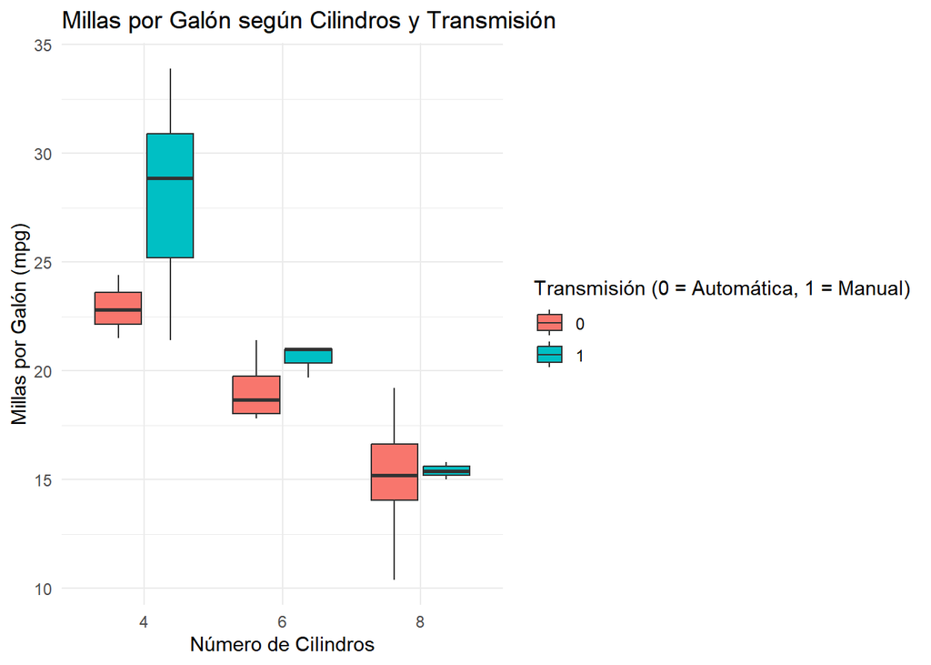

```r
# Crear un boxplot de mpg según el número de cilindros y transmisión
ggplot(dt_mtcars, aes(x = factor(cyl), y = mpg, fill = factor(am))) +
  geom_boxplot() +
  labs(title = "Millas por Galón según Cilindros y Transmisión",
       x = "Número de Cilindros",
       y = "Millas por Galón (mpg)",
       fill = "Transmisión (0 = Automática, 1 = Manual)") +
  theme_minimal()
```

**Explicación**: Este boxplot nos permite comparar la eficiencia de combustible (`mpg`) entre autos con diferente número de cilindros (`cyl`) y diferentes tipos de transmisión (`am`). Podemos observar las diferencias en las distribuciones y posibles valores atípicos dentro de cada grupo.

### 4.2 Violinplots: Comparación con factores

Un **violinplot** combina un boxplot con una representación de la distribución de los datos. Vamos a comparar la variable `mpg` con dos factores: número de **cilindros** (`cyl`) y transmisión (`am`).

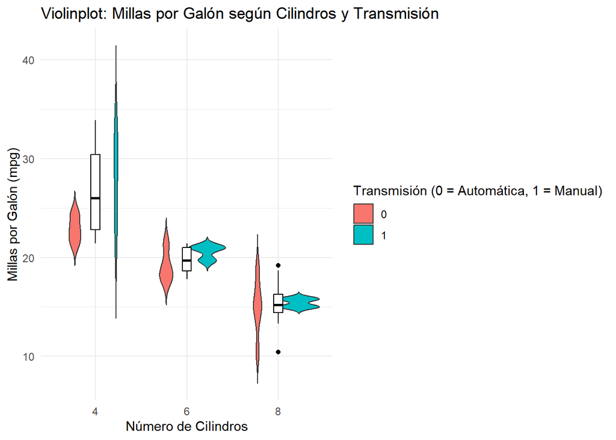

```r
# Crear un violinplot para mpg con factores
ggplot(dt_mtcars, aes(x = factor(cyl), y = mpg, fill = factor(am))) +
  geom_violin(trim = FALSE) +
  geom_boxplot(width = 0.1, fill = "white", color = "black") +
  labs(title = "Violinplot: Millas por Galón según Cilindros y Transmisión",
       x = "Número de Cilindros",
       y = "Millas por Galón (mpg)",
       fill = "Transmisión (0 = Automática, 1 = Manual)") +
  theme_minimal()
```

**Explicación**: El violinplot muestra la densidad de los datos para cada combinación de cilindros y tipo de transmisión. Combina la información de un boxplot con una representación más rica de la distribución.

## 5. Análisis Factorial con Boxplots para 3 Factores

### 5.1 Comparar la distribución de `mpg` en función de tres factores

Para realizar una comparación más avanzada, generaremos un boxplot que muestre la variable `mpg` en función de tres factores: número de **cilindros** (`cyl`), **transmisión** (`am`), y el número de **marchas** (`gear`).

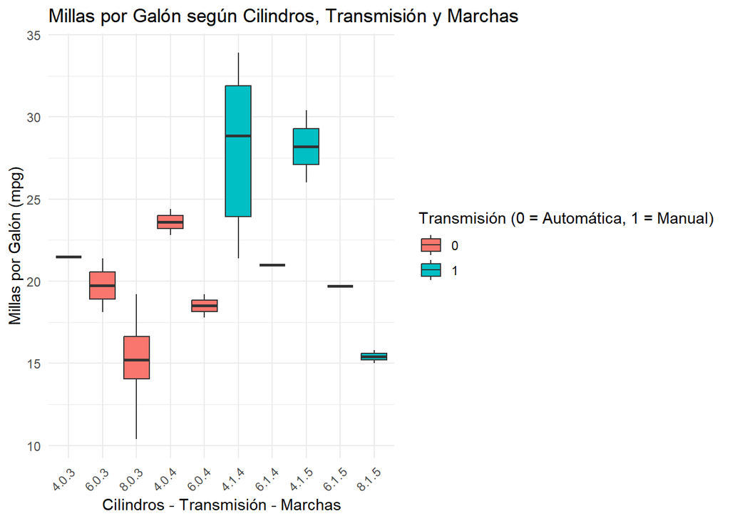

```r
# Crear un boxplot de mpg según cilindros, transmisión y marchas
ggplot(dt_mtcars, aes(x = interaction(cyl, am, gear), y = mpg, fill = factor(am))) +
  geom_boxplot() +
  labs(title = "Millas por Galón según Cilindros, Transmisión y Marchas",
       x = "Cilindros - Transmisión - Marchas",
       y = "Millas por Galón (mpg)",
       fill = "Transmisión (0 = Automática, 1 = Manual)") +
  theme_minimal() +
  theme(axis.text.x = element_text(angle = 45, hjust = 1))
```

**Explicación**: Este gráfico combina tres factores: el número de cilindros, el tipo de transmisión, y el número de marchas. Nos permite explorar cómo estos tres factores interactúan para influir en la eficiencia de combustible (mpg).

## 6. Ejercicios Prácticos

### **Ejercicio 1**: Realizar un análisis factorial

Utiliza la función `describe()` de `psych` para describir la variable `hp` en función de los factores `cyl` y `am`.

```r
# Tu código aquí
```

**Mostrar solución**

```r
# Solución
describeBy(dt_mtcars$hp, group = list(dt_mtcars$cyl, dt_mtcars$am))
```

```
##
##  Descriptive statistics by group
## : 4
## : 0
##    vars n  mean    sd median trimmed  mad min max range  skew kurtosis    se
## X1    1 3 84.67 19.66     95   84.67 2.97  62  97    35 -0.38    -2.33 11.35
## ------------------------------------------------------------
## : 6
## : 0
##    vars n   mean   sd median trimmed  mad min max range  skew kurtosis   se
## X1    1 4 115.25 9.18  116.5  115.25 9.64 105 123    18 -0.09    -2.33 4.59
## ------------------------------------------------------------
## : 8
## : 0
##    vars  n   mean    sd median trimmed   mad min max range skew kurtosis   se
## X1    1 12 194.17 33.36    180   193.5 40.77 150 245    95 0.28    -1.44 9.63
## ------------------------------------------------------------
## : 4
## : 1
##    vars n  mean    sd median trimmed   mad min max range skew kurtosis   se
## X1    1 8 81.88 22.66   78.5   81.88 20.76  52 113    61 0.14    -1.81 8.01
## ------------------------------------------------------------
## : 6
## : 1
##    vars n   mean    sd median trimmed mad min max range skew kurtosis    se
## X1    1 3 131.67 37.53    110  131.67   0 110 175    65 0.38    -2.33 21.67
## ------------------------------------------------------------
## : 8
## : 1
##    vars n  mean   sd median trimmed   mad min max range skew kurtosis   se
## X1    1 2 299.5 50.2  299.5   299.5 52.63 264 335    71    0    -2.75 35.5
```

### **Ejercicio 2**: Crear un violinplot

Crea un violinplot que compare la variable `hp` (caballos de fuerza) según el número de cilindros (`cyl`) y el número de marchas (`gear`).

```r
# Tu código aquí
```

**Mostrar solución**

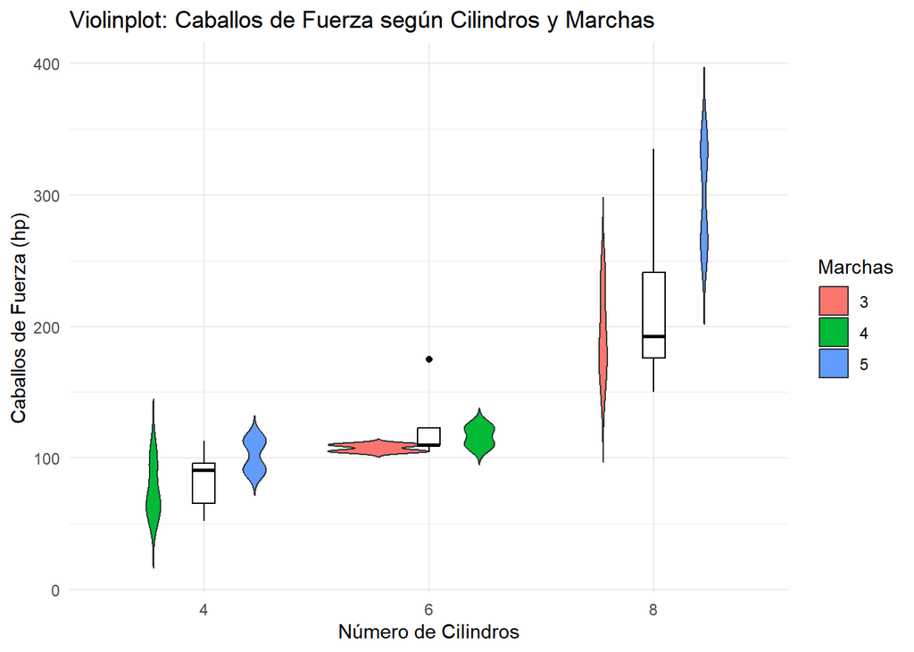

```r
# Solución
ggplot(dt_mtcars, aes(x = factor(cyl), y = hp, fill = factor(gear))) +
  geom_violin(trim = FALSE) +
  geom_boxplot(width = 0.1, fill = "white", color = "black") +
  labs(title = "Violinplot: Caballos de Fuerza según Cilindros y Marchas",
       x = "Número de Cilindros",
       y = "Caballos de Fuerza (hp)",
       fill = "Marchas") +
  theme_minimal()
```